# RISK PREDICTION OF DOMESTIC BATTERY FOR CHICAGO

Hanyong Xu

11/07/2019

In this analysis, the risk of domestic batteries in the city of Chicago is predicted using a machine learning model. Such a model could potentially increase the policing efficiency by directing officers where to focus for the patrols, but it might also suffer from the selection bias originated from different demographics. The accuracy and generalizability will be evaluated and a recommendation of whether the proposed model should be put into production will be delivered in the end.

## 1. setup

```r
library(tidyverse)
library(sf)
library(QuantPsyc)
library(RSocrata)
library(viridis)
library(caret)
library(spatstat)
library(spdep)
library(FNN)
library(grid)
library(gridExtra)
library(knitr)
library(kableExtra)
library(tidycensus)

mapTheme <- function(base_size = 10) {
  theme(
    text = element_text(color = "black"),
    plot.title = element_text(size = 12,colour = "black"),
    plot.subtitle=element_text(face="italic"),
    plot.caption=element_text(hjust=0),
    axis.ticks = element_blank(),
    panel.background = element_blank(),
    axis.title = element_blank(),
    strip.background = element_rect(fill = "white", color = "white"),
    strip.text.x = element_text(size = 8),
    axis.text = element_blank(),
    axis.title.x = element_blank(),
    axis.title.y = element_blank(),
    panel.grid.minor = element_blank(),
    #panel.border = element_rect(colour = "black", fill=NA, size=2)
  )
}
```

## 2. Data Wrangling

### 2.1 Outcome Variable

```r
chicagoBoundary <-
  st_read("C:/Users/HanyongXu/Documents/Me/grad/fall_2019/MUSA507/Week_9/riskPrediction_data/chicagoBoundary.shp") %>%
  st_transform(crs=102271)

fishnet <-
  st_make_grid(chicagoBoundary, cellsize = 500) %>%
  st_sf()
```

```r
policeDistricts <-
  st_read("https://data.cityofchicago.org/api/geospatial/fthy-xz3r?method=export&format=GeoJSON") %>%
  st_transform(crs=102271) %>%
  dplyr::select(District = dist_num)

policeBeats <-
  st_read("https://data.cityofchicago.org/api/geospatial/aerh-rz74?method=export&format=GeoJSON") %>%
  st_transform(crs=102271) %>%
  dplyr::select(District = beat_num)

bothPoliceUnits <- rbind(mutate(policeDistricts, Legend = "Police Districts"),
                         mutate(policeBeats, Legend = "Police Beats"))
```

Domestic battery in 2018 is chosen as the outcome variable. It is downloaded from the [Chicago Open Data](https://data.cityofchicago.org/) website. Its distribution is mapped below. The selection bias for this crime is mostly from reporting bias. This variable is prone to selection bias for three reasons: 1) people experiencing domestic violence are often afraid of reporting the violence, they may be afraid of worsening the family relationship or reputation; 2) victims are sometimes not aware of their rights to report, or have no means of reporting, especially for children; 3) domestic violence is hard to be reported by people from the outside since it happens inside a household. The bias is likely linked to race and education levels, which will be discussed in the later sections of this markdown.

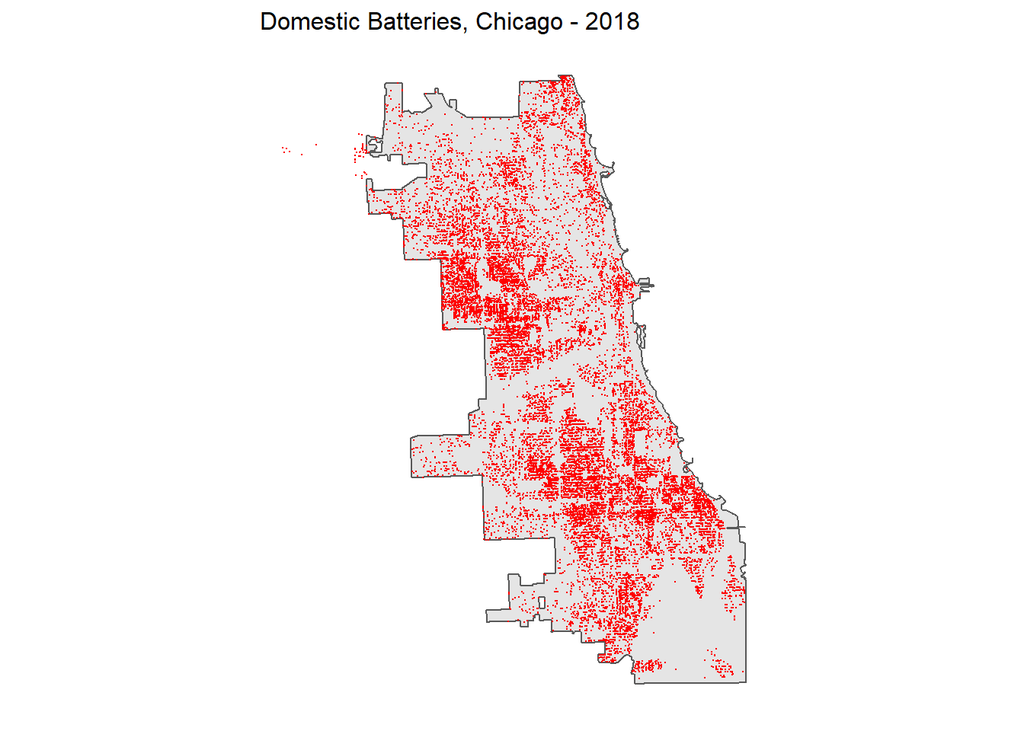

```r
dbatt <-
  read.socrata("https://data.cityofchicago.org/Public-Safety/Crimes-2018/3i3m-jwuy") %>%
  filter(Primary.Type == "BATTERY" &
         grepl('DOMESTIC', Description)) %>%
  mutate(x = gsub("[()]", "", Location)) %>%
  separate(x,into= c("Y","X"), sep=",") %>%
  mutate(X = as.numeric(X),
         Y = as.numeric(Y)) %>%
  na.omit %>%
  st_as_sf(coords = c("X", "Y"), crs = 4326, agr = "constant")%>%
  st_transform(102271) %>%
  distinct()

ggplot() +
  geom_sf(data = chicagoBoundary) +
  geom_sf(data = dbatt, colour="red", size=0.05, show.legend = "point") +
  labs(title= "Domestic Batteries, Chicago - 2018") +
  mapTheme()
```

The domestic battery point data is joined to the fishnet grid to count for the number of incidences in each grid.

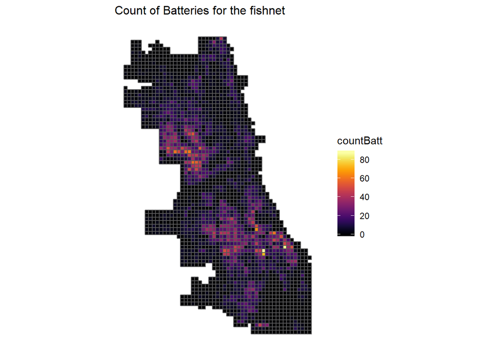

```r
crime_net <-
  dbatt %>%
  dplyr::select() %>%
  mutate(countBatt = 1) %>%
  aggregate(., fishnet, sum) %>%
  mutate(countBatt = ifelse(is.na(countBatt), 0, countBatt),
         uniqueID = rownames(.),
         cvID = sample(round(nrow(fishnet) / 24), size=nrow(fishnet), replace = TRUE))

ggplot() +
  geom_sf(data = crime_net, aes(fill = countBatt)) +
  scale_fill_viridis(option = "B") +
  labs(title = "Count of Batteries for the fishnet") +
  mapTheme()
```

### 2.2 Risk Factors / Predictors

The risk factors data are downloaded from the [Chicago Open Data](https://data.cityofchicago.org/) as well. Risk factors used include: abandoned cars, abandoned buildings, graffiti, street lights out, sanitation problems, liquor retailors, family support centers, connect centers for jobs, and health clinics. Family support centers and connect centers might support families, foster social interactions, and create opportunities for public supervision. The health clinics provide the people the access to both mental and physical health treatment. These predictors are joined to the fishnet and plotted below.

Other predictors include the neighborhood, the police beats and districts, and the distance to The Loop.

```r
abandonCars <-
  read.socrata("https://data.cityofchicago.org/Service-Requests/311-Service-Requests-Abandoned-Vehicles/3c9v-pnva") %>%
  mutate(year = substr(creation_date,1,4)) %>%
  filter(year == "2018") %>%
  dplyr::select(Y = latitude, X = longitude) %>%
  na.omit() %>%
  st_as_sf(coords = c("X", "Y"), crs = 4326, agr = "constant") %>%
  st_transform(st_crs(fishnet)) %>%
  mutate(Legend = "Abandoned_Cars")

abandonBuildings <-
  read.socrata("https://data.cityofchicago.org/Service-Requests/311-Service-Requests-Vacant-and-Abandoned-Building/7nii-7srd") %>%
    mutate(year = substr(date_service_request_was_received,1,4)) %>%
    filter(year == "2018") %>%
    dplyr::select(Y = latitude, X = longitude) %>%
  na.omit() %>%
  st_as_sf(coords = c("X", "Y"), crs = 4326, agr = "constant") %>%
  st_transform(st_crs(fishnet)) %>%
  mutate(Legend = "Abandoned_Buildings")

graffiti <-
  read.socrata("https://data.cityofchicago.org/Service-Requests/311-Service-Requests-Graffiti-Removal-Historical/hec5-y4x5") %>%
    mutate(year = substr(creation_date,1,4)) %>%
    filter(year == "2018") %>%
    filter(where_is_the_graffiti_located_ == "Front" |
           where_is_the_graffiti_located_ == "Rear" | where_is_the_graffiti_located_ == "Side") %>%
    dplyr::select(Y = latitude, X = longitude) %>%
  na.omit() %>%
  st_as_sf(coords = c("X", "Y"), crs = 4326, agr = "constant") %>%
  st_transform(st_crs(fishnet)) %>%
  mutate(Legend = "Graffiti")

streetLightsOut <-
  read.socrata("https://data.cityofchicago.org/Service-Requests/311-Service-Requests-Street-Lights-All-Out/zuxi-7xem") %>%
    mutate(year = substr(creation_date,1,4)) %>%
    filter(year == "2018") %>%
    dplyr::select(Y = latitude, X = longitude) %>%
  na.omit() %>%
  st_as_sf(coords = c("X", "Y"), crs = 4326, agr = "constant") %>%
  st_transform(st_crs(fishnet)) %>%
  mutate(Legend = "Street_Lights_Out")

sanitation <-
  read.socrata("https://data.cityofchicago.org/Service-Requests/311-Service-Requests-Sanitation-Code-Complaints-Hi/me59-5fac") %>%
    mutate(year = substr(creation_date,1,4)) %>%
    filter(year == "2018") %>%
    dplyr::select(Y = latitude, X = longitude) %>%
  na.omit() %>%
  st_as_sf(coords = c("X", "Y"), crs = 4326, agr = "constant") %>%
  st_transform(st_crs(fishnet)) %>%
  mutate(Legend = "Sanitation")

liquorRetail <-
  read.socrata("https://data.cityofchicago.org/Community-Economic-Development/Business-Licenses-Cur   rent-Liquor-and-Public-Places/nrmj-3kcf") %>%
  filter(BUSINESS.ACTIVITY == "Retail Sales of Packaged Liquor") %>%
  dplyr::select(Y = LATITUDE, X = LONGITUDE) %>%
  na.omit() %>%
  st_as_sf(coords = c("X", "Y"), crs = 4326, agr = "constant") %>%
  st_transform(st_crs(fishnet)) %>%
  mutate(Legend = "Liquor_Retail")

neighborhoods <-
  st_read("https://raw.githubusercontent.com/blackmad/neighborhoods/master/chicago.geojson") %>%
  st_transform(st_crs(fishnet))

familysupport <-
  read.socrata("https://data.cityofchicago.org/resource/jmw7-ijg5.json") %>%
  filter(division == "Domestic Violence") %>%
  dplyr::select(Y = latitude, X = longitude) %>%
  na.omit() %>%
  st_as_sf(coords = c("X", "Y"), crs = 4326, agr = "constant") %>%
  st_transform(st_crs(fishnet)) %>%
  mutate(Legend = "Family_Support")
#from https://data.cityofchicago.org/Health-Human-Services/Family-and-Support-Services-Delegate-Agencies/tmqa-hyf7

connectcenters <-
  read.socrata("https://data.cityofchicago.org/resource/bmus-hp7e.json") %>%
  dplyr::select(Y = latitude, X = longitude) %>%
  na.omit() %>%
  st_as_sf(coords = c("X", "Y"), crs = 4326, agr = "constant") %>%
  st_transform(st_crs(fishnet)) %>%
  mutate(Legend = "Connect_Center")
#from https://data.cityofchicago.org/Education/Connect-Chicago-Locations/bmus-hp7e

healthclinic <-
  read.socrata("https://data.cityofchicago.org/resource/kcki-hnch.json") %>%
  dplyr::select(Y = latitude, X = longitude) %>%
  na.omit() %>%
  st_as_sf(coords = c("X", "Y"), crs = 4326, agr = "constant") %>%
  st_transform(st_crs(fishnet)) %>%
  mutate(Legend = "Health_Clinic")
#from https://data.cityofchicago.org/Health-Human-Services/Chicago-Department-of-Public-Health-Clinic-Locatio/kcki-hnch
```

```r
vars_net <-
  rbind(abandonCars,streetLightsOut,abandonBuildings,
        liquorRetail, graffiti, sanitation, familysupport,
        connectcenters, healthclinic) %>%
  st_join(., fishnet, join=st_within) %>%
  st_set_geometry(NULL) %>%
  group_by(uniqueID, Legend) %>%
  summarize(count = n()) %>%
  full_join(fishnet) %>%
  spread(Legend, count, fill=0) %>%
  st_sf() %>%
  dplyr::select(-`<NA>`) %>%
  na.omit()

vars_net
```

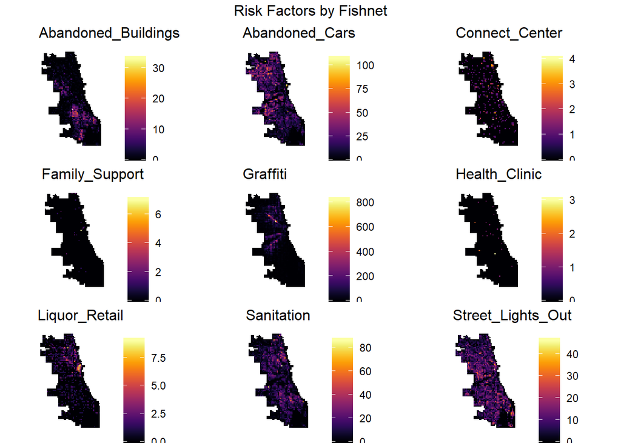

```r
vars_net.long <-
  vars_net %>%
  gather(Variable, value, -geometry, -uniqueID)

vars <- unique(vars_net.long$Variable)
mapList <- list()

for(i in vars){
  mapList[[i]] <-
    ggplot() +
      geom_sf(data = filter(vars_net.long, Variable == i), aes(fill=value), colour=NA) +
      scale_fill_viridis(name="", option = "B") +
      labs(title=i) +
      mapTheme()}

do.call(grid.arrange,c(mapList, ncol =3, top = "Risk Factors by Fishnet"))
```

## 3. Feature Engineering

### 3.1 Nearest Neighbor Features

To better capture the spatial quality of the predictors, the distance of each crime data point to the closest of each amenity/risk is calculated. For certain factors, three or five closest neighboring amenities/risks are chosen for the calculation because of their high density. These new features are then joined with the fishnet and plotted below.

```r
nn_function <- function(measureFrom,measureTo,k) {
  measureFrom_Matrix <-
    as.matrix(measureFrom)
  measureTo_Matrix <-
    as.matrix(measureTo)
  nn <-
    get.knnx(measureTo, measureFrom, k)$nn.dist
    output <-
      as.data.frame(nn) %>%
      rownames_to_column(var = "thisPoint") %>%
      gather(points, point_distance, V1:ncol(.)) %>%
      arrange(as.numeric(thisPoint)) %>%
      group_by(thisPoint) %>%
      summarize(pointDistance = mean(point_distance)) %>%
      arrange(as.numeric(thisPoint)) %>%
      dplyr::select(-thisPoint) %>%
      pull()

  return(output)
}
```

```r
vars_net$Abandoned_Buildings.nn5 =
    nn_function(st_coordinates(st_centroid(vars_net)), st_coordinates(abandonBuildings), 5)
vars_net$Abandoned_Buildings.nn3 =
    nn_function(st_coordinates(st_centroid(vars_net)), st_coordinates(abandonBuildings), 3)
vars_net$Abandoned_Buildings.nn1 =
    nn_function(st_coordinates(st_centroid(vars_net)), st_coordinates(abandonBuildings), 1)

vars_net$Abandoned_Cars.nn3 =
    nn_function(st_coordinates(st_centroid(vars_net)), st_coordinates(abandonCars), 3)
vars_net$Abandoned_Cars.nn1 =
    nn_function(st_coordinates(st_centroid(vars_net)), st_coordinates(abandonCars), 1)

vars_net$Graffiti.nn5 =
    nn_function(st_coordinates(st_centroid(vars_net)), st_coordinates(graffiti), 5)
vars_net$Graffiti.nn3 =
    nn_function(st_coordinates(st_centroid(vars_net)), st_coordinates(graffiti), 3)
vars_net$Graffiti.nn1 =
    nn_function(st_coordinates(st_centroid(vars_net)), st_coordinates(graffiti), 1)

vars_net$Liquor_Retail.nn3 =
    nn_function(st_coordinates(st_centroid(vars_net)), st_coordinates(liquorRetail), 3)
vars_net$Liquor_Retail.nn1 =
    nn_function(st_coordinates(st_centroid(vars_net)), st_coordinates(liquorRetail), 1)

vars_net$Street_Lights_Out.nn5 =
    nn_function(st_coordinates(st_centroid(vars_net)), st_coordinates(streetLightsOut), 5)
vars_net$Street_Lights_Out.nn3 =
    nn_function(st_coordinates(st_centroid(vars_net)), st_coordinates(streetLightsOut), 3)
vars_net$Street_Lights_Out.nn1 =
    nn_function(st_coordinates(st_centroid(vars_net)), st_coordinates(streetLightsOut), 1)

vars_net$Sanitation.nn3 =
    nn_function(st_coordinates(st_centroid(vars_net)), st_coordinates(sanitation), 3)
vars_net$Sanitation.nn1 =
    nn_function(st_coordinates(st_centroid(vars_net)), st_coordinates(sanitation), 1)

vars_net$Family_Support.nn1 =
    nn_function(st_coordinates(st_centroid(vars_net)), st_coordinates(familysupport), 1)

vars_net$ConnectCenter.nn3 =
    nn_function(st_coordinates(st_centroid(vars_net)), st_coordinates(connectcenters), 3)
vars_net$ConnectCenter.nn1 =
    nn_function(st_coordinates(st_centroid(vars_net)), st_coordinates(connectcenters), 1)

vars_net$healthClinic.nn1 =
    nn_function(st_coordinates(st_centroid(vars_net)), st_coordinates(healthclinic), 1)
```

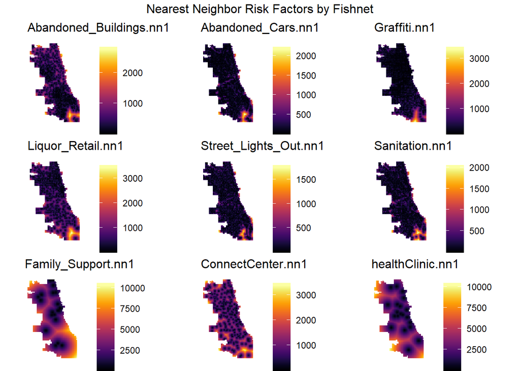

```r
vars_net.long.nn1 <-
  vars_net %>%
  dplyr::select(ends_with(".nn1")) %>%
  gather(Variable, value, -geometry, -uniqueID)

vars <- unique(vars_net.long.nn1$Variable)
mapList <- list()

for(i in vars){
  mapList[[i]] <-
    ggplot() +
      geom_sf(data = filter(vars_net.long.nn1, Variable == i), aes(fill=value), colour=NA) +
      scale_fill_viridis(name="", option = "B") +
      labs(title=i) +
      mapTheme()}

do.call(grid.arrange,c(mapList, ncol =3, top = "Nearest Neighbor Risk Factors by Fishnet"))
```

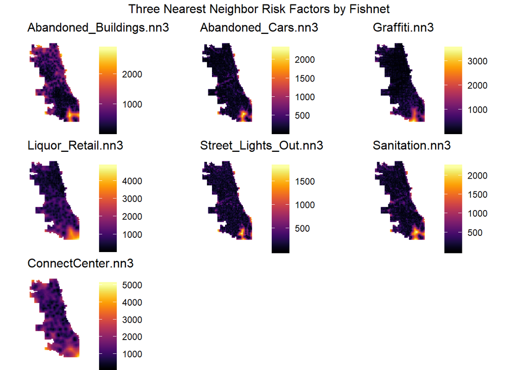

```r
vars_net.long.nn3 <-
  vars_net %>%
  dplyr::select(ends_with(".nn3")) %>%
  gather(Variable, value, -geometry, -uniqueID)

vars <- unique(vars_net.long.nn3$Variable)
mapList <- list()

for(i in vars){
  mapList[[i]] <-
    ggplot() +
      geom_sf(data = filter(vars_net.long.nn3, Variable == i), aes(fill=value), colour=NA) +
      scale_fill_viridis(name="", option = "B") +
      labs(title=i) +
      mapTheme()}

do.call(grid.arrange,c(mapList, ncol =3, top = "Three Nearest Neighbor Risk Factors by Fishnet"))
```

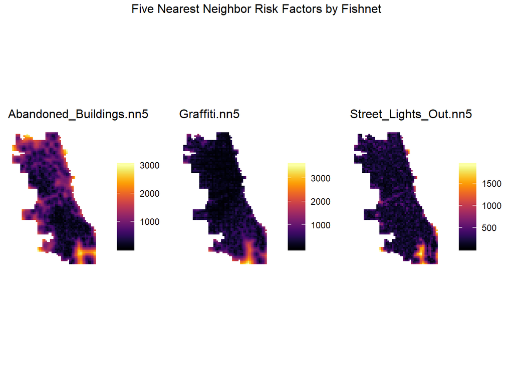

```r
vars_net.long.nn5 <-
  vars_net %>%
  dplyr::select(ends_with(".nn5")) %>%
  gather(Variable, value, -geometry, -uniqueID)

vars <- unique(vars_net.long.nn5$Variable)
mapList <- list()

for(i in vars){
  mapList[[i]] <-
    ggplot() +
      geom_sf(data = filter(vars_net.long.nn5, Variable == i), aes(fill=value), colour=NA) +
      scale_fill_viridis(name="", option = "B") +
      labs(title=i) +
      mapTheme()}

do.call(grid.arrange,c(mapList, ncol =3, top = "Five Nearest Neighbor Risk Factors by Fishnet"))
```

### 3.2 Measure Distance to One Point

The distance to The Loop, or the downtown area of Chicago is calculated as an additional predictor.

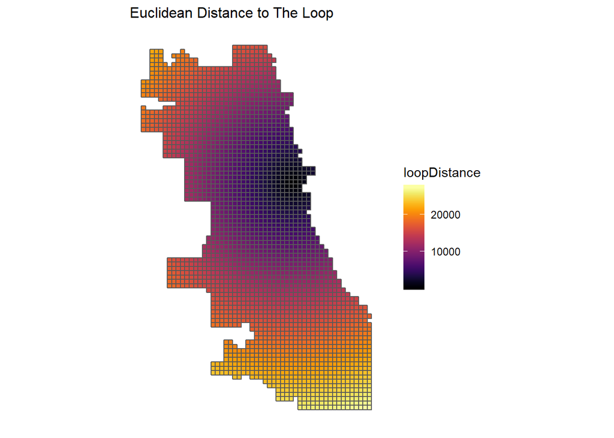

```r
loopPoint <-
  neighborhoods %>%
  filter(name == "Loop") %>%
  st_centroid()

vars_net$loopDistance =
  st_distance(st_centroid(vars_net),loopPoint) %>%
  as.numeric()

ggplot() +
  geom_sf(data=vars_net, aes(fill=loopDistance)) +
  scale_fill_viridis(option = "B") +
  labs(title="Euclidean Distance to The Loop") +
  mapTheme()
```

### 3.3 Join with Neighborhoods and Police Districts

The data above are joined together with the neighborhood and the police districts data.

```r
final_net <-
  left_join(crime_net, st_set_geometry(vars_net, NULL), by="uniqueID")
```

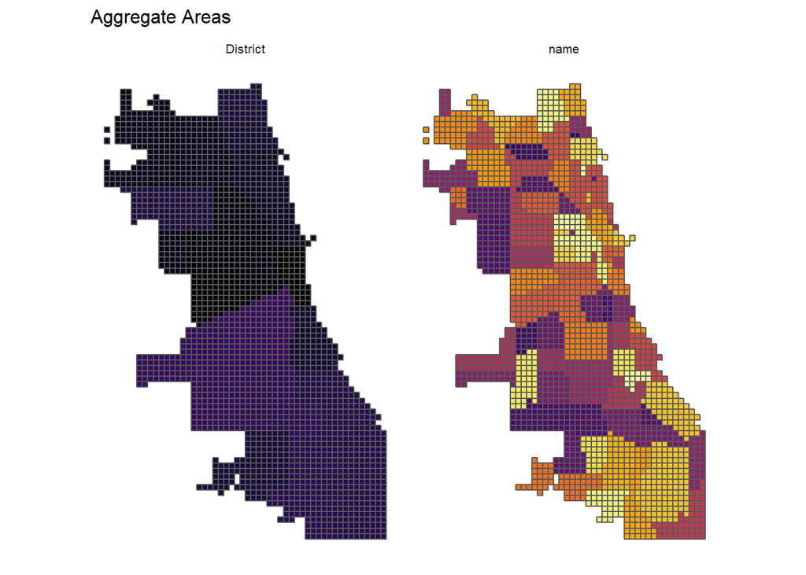

```r
final_net <-
  st_centroid(final_net) %>%
    st_join(., dplyr::select(neighborhoods, name)) %>%
    st_join(., dplyr::select(policeDistricts, District)) %>%
      st_set_geometry(NULL) %>%
      left_join(dplyr::select(final_net, geometry, uniqueID)) %>%
      st_sf() %>%
  na.omit()

dplyr::select(final_net, name, District) %>%
  gather(Variable, Value, -geometry) %>%
    ggplot() +
      geom_sf(aes(fill = Value)) +
      facet_wrap(~Variable) +
      scale_fill_viridis(discrete = TRUE, option = "B") +
      labs(title = "Aggregate Areas") +
      mapTheme() + theme(legend.position = "none")
```

### 3.4 Exploring the Spatial Structure of Battery

Local Moran’s I is calculated to find the existing spatial autocorrelation of the domestic batty crimes. A hotspot is also mapped below showing the highly significant risky regions.

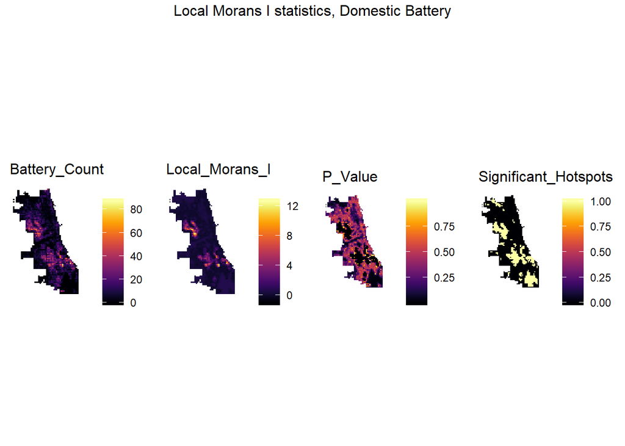

```r
final_net.localMorans <-
  cbind(
    as.data.frame(localmoran(final_net$countBatt, final_net.weights)),
    as.data.frame(final_net, NULL)) %>%
    st_sf() %>%
    dplyr::select(Battery_Count = countBatt,
                  Local_Morans_I = Ii,
                  P_Value = `Pr(z > 0)`) %>%
    mutate(Significant_Hotspots = ifelse(P_Value <= 0.05, 1, 0)) %>%
    gather(Variable, Value, -geometry)

vars <- unique(final_net.localMorans$Variable)
varList <- list()

for(i in vars){
  varList[[i]] <-
    ggplot() +
      geom_sf(data = filter(final_net.localMorans, Variable == i), aes(fill = Value), colour=NA) +
      scale_fill_viridis(name="", option = "B") +
      labs(title=i) +
      mapTheme()}

do.call(grid.arrange,c(varList, ncol = 4, top = "Local Morans I statistics, Domestic Battery"))
```

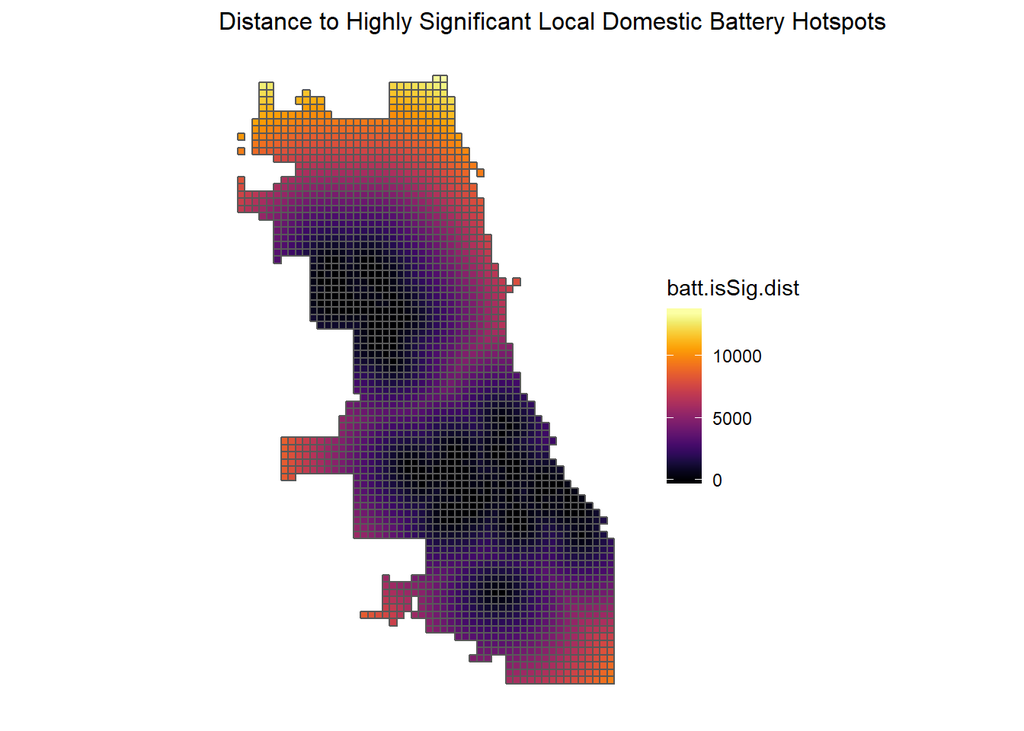

```r
final_net <-
  final_net %>%
  mutate(batt.isSig = ifelse(localmoran(final_net$countBatt,
                                            final_net.weights)[,5] <= 0.0000001, 1, 0)) %>%
  mutate(batt.isSig.dist = nn_function(st_coordinates(st_centroid(final_net)),
                                           st_coordinates(st_centroid(
                                             filter(final_net, batt.isSig == 1))), 1 ))

ggplot() +
  geom_sf(data = final_net, aes(fill = batt.isSig.dist)) +
  scale_fill_viridis(option = "B") +
  labs(title = "Distance to Highly Significant Local Domestic Battery Hotspots") +
  mapTheme()
```

### 3.5 Correlation Tests of the Risk Factors

Both the predictors mentioned above and the engineered features are plotted against the outcome variable, the domestic battery counts. Note that only one engineered feature is chosen for each risk factor. The ‘r’ numbers demonstrate the correlation between the predictors and the dependent variable.

```r
correlation.long <-
  st_set_geometry(final_net, NULL) %>%
    dplyr::select(-uniqueID, -cvID, -loopDistance, -name, -District,
                   -batt.isSig, -batt.isSig.dist, -Abandoned_Buildings.nn3, -Abandoned_Buildings.nn1, -Abandoned_Cars.nn1, -Graffiti.nn1, -Graffiti.nn5, -Street_Lights_Out.nn1, -Street_Lights_Out.nn3, -Liquor_Retail.nn3, -Sanitation.nn1, -ConnectCenter.nn1) %>%
    gather(Variable, Value, -countBatt)
```

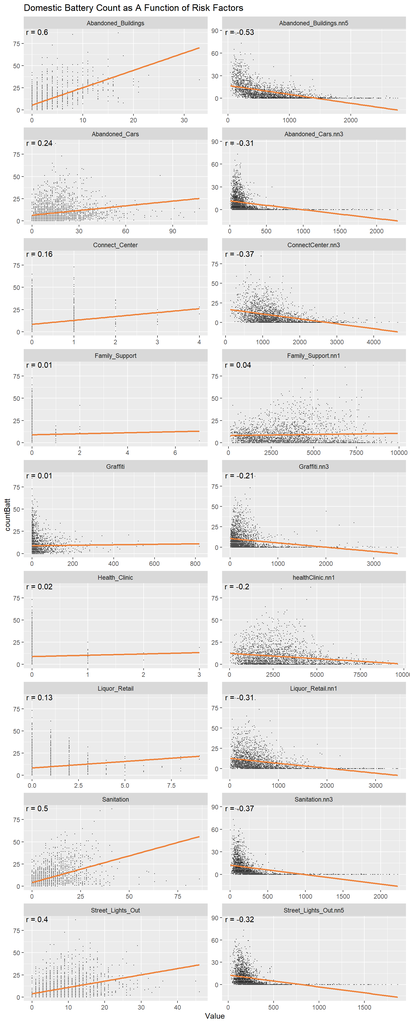

```r
correlation.cor <-
  correlation.long %>%
    group_by(Variable) %>%
    summarize(correlation = cor(as.numeric(Value), countBatt, use = "complete.obs"))

ggplot(correlation.long, aes(Value, countBatt)) +
  geom_point(size = 0.1) +
  geom_text(data = correlation.cor, aes(label = paste("r =", round(correlation, 2))),
            x=-Inf, y=Inf, vjust = 1, hjust = -.1) +
  geom_smooth(method = "lm", se = FALSE, colour = "#ee8138") +
  facet_wrap(~Variable, ncol = 2, scales = "free") +
  labs(title = "Domestic Battery Count as A Function of Risk Factors")
```

## 4. Regression and Validation

### 4.1 Poisson Regression

Poisson regression is chosen as the model to use here because crime is happening in low probability in general, thus, using a binomial logit model might leads to unreasonable thresholds selection.

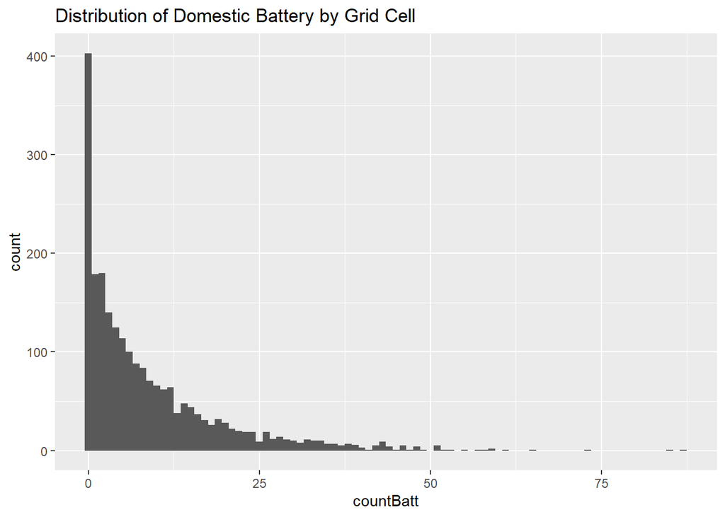

```r
ggplot(final_net, aes(countBatt)) +
  geom_histogram(binwidth = 1) +
  labs(title = "Distribution of Domestic Battery by Grid Cell")
```

### 4.2 Cross-validated Poisson Regression

There are two cross-validations conducted. The first type seperate the dataset into 100 folds, and each fold is tested when the rest of the data are trained. The second type use the neighborhood to do the cross validation: each neighborhood of data is tested when the rest of the data are trained.

There are two sets of input data. The first set does not include spatial structures while the seconde set does. Only one features from each variable is selected to avoid multicollinearity. The Family Support Center predictor is dropped since it has little correlation and results in higher MAE.

```r
reg.vars <- c("Abandoned_Buildings.nn5", "Abandoned_Cars.nn3", "Graffiti.nn3",
              "Liquor_Retail.nn1", "Street_Lights_Out.nn5", "Sanitation.nn3", "loopDistance",
              "healthClinic.nn1", "ConnectCenter.nn3")

reg.ss.vars <- c("Abandoned_Buildings.nn5", "Abandoned_Cars.nn3", "Graffiti.nn3",
                 "Liquor_Retail.nn1", "Street_Lights_Out.nn5", "Sanitation.nn3", "loopDistance",
                 "healthClinic.nn1", "ConnectCenter.nn3",
                 "batt.isSig", "batt.isSig.dist")
```

```r
crossValidate <- function(dataset, id, dependentVariable, indVariables) {

allPredictions <- data.frame()
cvID_list <- unique(dataset[[id]])

for (i in cvID_list) {

  thisFold <- i
  cat("This hold out fold is", thisFold, "\n")

  fold.train <- filter(dataset, dataset[[id]] != thisFold) %>% as.data.frame() %>%
                dplyr::select(id, geometry, indVariables, dependentVariable)
  fold.test  <- filter(dataset, dataset[[id]] == thisFold) %>% as.data.frame() %>%
                dplyr::select(id, geometry, indVariables, dependentVariable)

  regression <-
    glm(countBatt ~ ., family = "poisson",
      data = fold.train %>%
      dplyr::select(-geometry, -id))

  thisPrediction <-
    mutate(fold.test, Prediction = predict(regression, fold.test, type = "response"))

  allPredictions <-
    rbind(allPredictions, thisPrediction)

  }
  return(st_sf(allPredictions))
}
```

## 5. Accuracy and Generalzability

### 5.1 Predicted Results

```r
reg.summary <-
  rbind(
    mutate(reg.cv,           Error = countBatt - Prediction,
                             Regression = "Random k-fold CV: Just Risk Factors"),

    mutate(reg.ss.cv,        Error = countBatt - Prediction,
                             Regression = "Random k-fold CV: Spatial Structure"),

    mutate(reg.spatialCV,    Error = countBatt - Prediction,
                             Regression = "Spatial LOGO-CV: Just Risk Factors"),

    mutate(reg.ss.spatialCV, Error = countBatt - Prediction,
                             Regression = "Spatial LOGO-CV: Spatial Structure")) %>%
    st_sf()
```

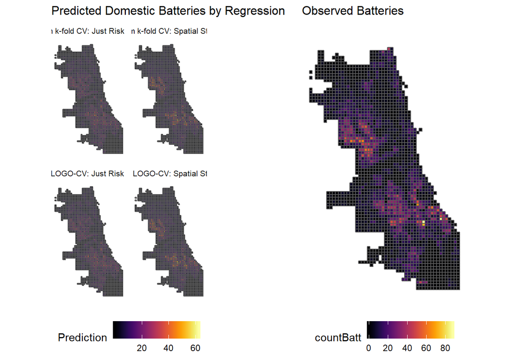

```r
grid.arrange(
  reg.summary %>%
    ggplot() +
      geom_sf(aes(fill = Prediction)) +
      facet_wrap(~Regression) +
      scale_fill_viridis(option = "B") +
      labs(title = "Predicted Domestic Batteries by Regression") +
      mapTheme() + theme(legend.position="bottom"),

  filter(reg.summary, Regression == "Random k-fold CV: Just Risk Factors") %>%
    ggplot() +
      geom_sf(aes(fill = countBatt)) +
      scale_fill_viridis(option = "B") +
      labs(title = "Observed Batteries\n") +
      mapTheme() + theme(legend.position="bottom"), ncol = 2)
```

### 5.2 Predicted Errors

From both the maps and the table below, one can tell that the models with the spatial structure perform better with lower errors. The error is greater for leave-one-group-out cross validation (LOGO cv) than that of the k-fold cross validation. The LOGO cv reflects the model’s ability to generalize across neighborhoods.

The MAE is around 3.9, which means on average the prediction deviates from the true counts by 3.9 counts of domestic batteries. For context, the mean of the `countBatt` is 8.969155.

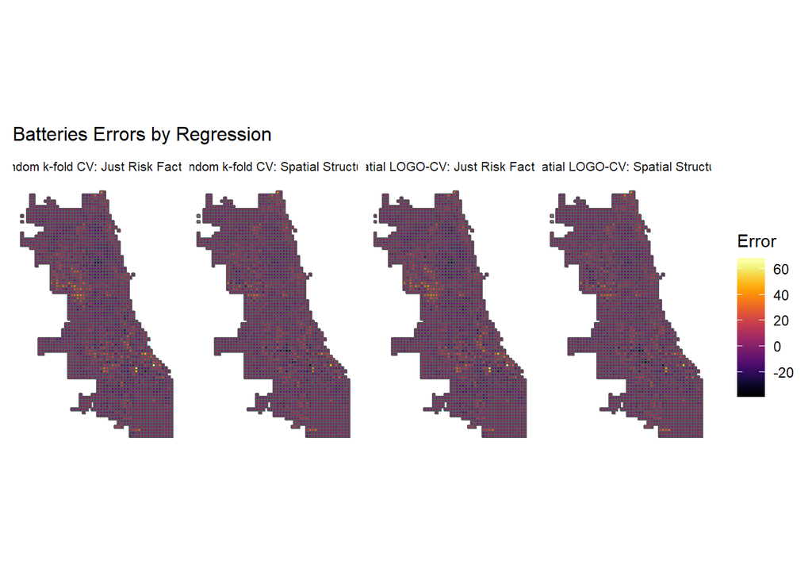

```r
filter(reg.summary,
       Regression == "Random k-fold CV: Just Risk Factors" |
       Regression == "Random k-fold CV: Spatial Structure" |
       Regression == "Spatial LOGO-CV: Just Risk Factors" |
       Regression == "Spatial LOGO-CV: Spatial Structure") %>%
  ggplot() +
    geom_sf(aes(fill = Error)) +
    facet_wrap(~Regression, ncol=4) +
    scale_fill_viridis(option = "B") +
    labs(title = "Batteries Errors by Regression") +
    mapTheme()
```

```r
st_set_geometry(reg.summary, NULL) %>%
  group_by(Regression) %>%
  summarize(MAE = round(mean(abs(Prediction - countBatt), na.rm = T),2),
            SD_MAE = round(sd(abs(Prediction - countBatt), na.rm = T),2)) %>%
  kable(caption = "MAE by Regression") %>%
    kable_styling("striped", full_width = F) %>%
    row_spec(2, color = "black", background = "#FDE725FF") %>%
    row_spec(4, color = "black", background = "#FDE725FF")
```

MAE by Regression

| Regression | MAE | SD_MAE |
| --- | --- | --- |
| Random k-fold CV: Just Risk Factors | 4.66 | 5.58 |
| Random k-fold CV: Spatial Structure | 3.85 | 4.47 |
| Spatial LOGO-CV: Just Risk Factors | 4.73 | 5.68 |
| Spatial LOGO-CV: Spatial Structure | 3.91 | 4.57 |

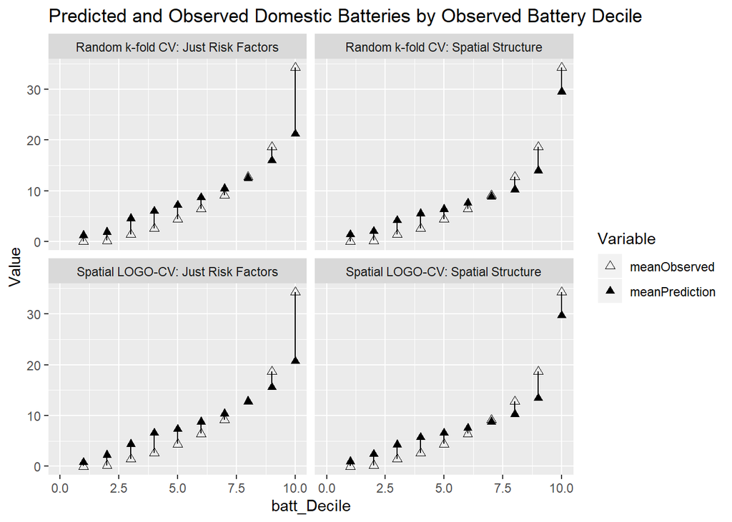

```r
st_set_geometry(reg.summary, NULL) %>%
  group_by(Regression) %>%
    mutate(batt_Decile = ntile(countBatt, 10)) %>%
  group_by(Regression, batt_Decile) %>%
    summarize(meanObserved = mean(countBatt, na.rm=T),
              meanPrediction = mean(Prediction, na.rm=T)) %>%
    gather(Variable, Value, -Regression, -batt_Decile) %>%
    ggplot(aes(batt_Decile, Value, shape = Variable)) +
      geom_point(size = 2) + geom_path(aes(group = batt_Decile), colour = "black") +
      scale_shape_manual(values = c(2, 17)) +
      facet_wrap(~Regression) + xlim(0,10) +
      labs(title = "Predicted and Observed Domestic Batteries by Observed Battery Decile")
```

### 5.3 Generalizability by Neighborhood Racial Context

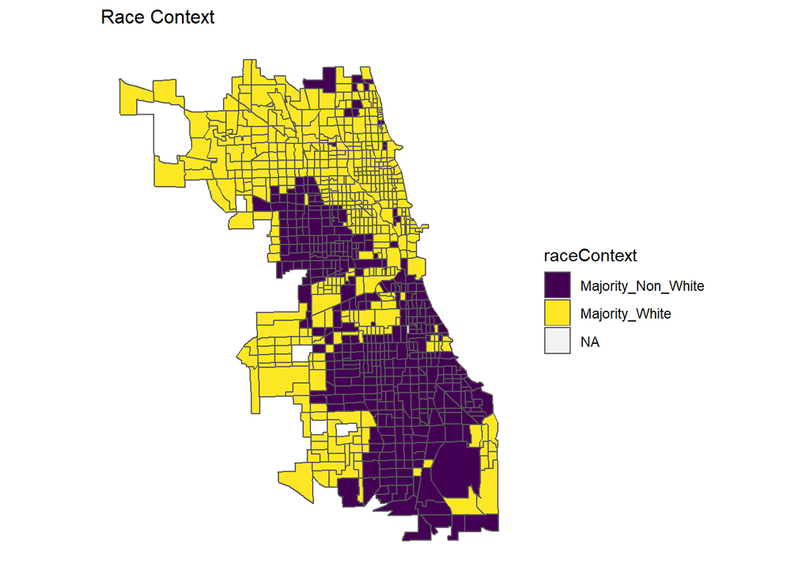

```r
ggplot() +
  geom_sf(data = tracts17r, aes(fill = raceContext)) +
  scale_fill_viridis(discrete = TRUE) +
  labs(title = "Race Context", name="Race Context") +
  mapTheme()
```

```r
final_reg <-
  filter(reg.summary, Regression == "Spatial LOGO-CV: Spatial Structure" |
                      Regression == "Spatial LOGO-CV: Just Risk Factors") %>%
  mutate(uniqueID = rownames(.))

final_reg.tractsr <-
  st_join(st_centroid(final_reg), tracts17r) %>%
    st_set_geometry(NULL) %>%
    left_join(dplyr::select(final_reg, uniqueID)) %>%
    st_sf() %>%
    na.omit()

st_set_geometry(final_reg.tractsr, NULL) %>%
  group_by(Regression, raceContext) %>%
  summarize(mean.Error = mean(Error, na.rm = T)) %>%
  spread(raceContext, mean.Error) %>%
  kable(caption = "Mean Error by Neighborhood Race Context") %>%
    kable_styling("striped", full_width = F)
```

Mean Error by Neighborhood Race Context

| Regression | Majority_Non_White | Majority_White |
| --- | --- | --- |
| Spatial LOGO-CV: Just Risk Factors | 1.4493207 | -1.4751385 |
| Spatial LOGO-CV: Spatial Structure | 0.6678826 | -0.6521197 |

### 5.4 Generalizability by Neighborhood Education Context

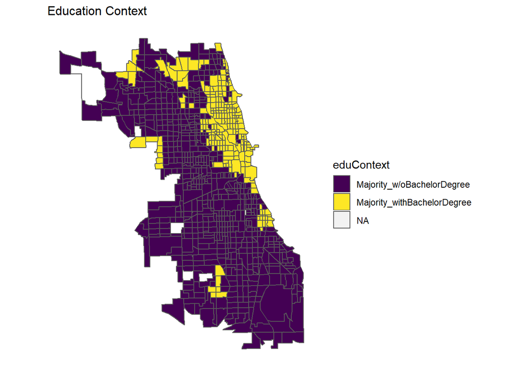

```r
ggplot() +
  geom_sf(data = tracts17, aes(fill = eduContext)) +
  scale_fill_viridis(discrete = TRUE) +
  labs(title = "Education Context", name="Education Context") +
  mapTheme()
```

```r
final_reg.tracts <-
  st_join(st_centroid(final_reg), tracts17) %>%
    st_set_geometry(NULL) %>%
    left_join(dplyr::select(final_reg, uniqueID)) %>%
    st_sf() %>%
    na.omit()

st_set_geometry(final_reg.tracts, NULL) %>%
  group_by(Regression, eduContext) %>%
  summarize(mean.Error = mean(Error, na.rm = T)) %>%
  spread(eduContext, mean.Error) %>%
  kable(caption = "Mean Error by Neighborhood Education Context") %>%
    kable_styling("striped", full_width = F)
```

Mean Error by Neighborhood Education Context

| Regression | Majority_w/oBachelorDegree | Majority_withBachelorDegree |
| --- | --- | --- |
| Spatial LOGO-CV: Just Risk Factors | 0.5337385 | -2.073558 |
| Spatial LOGO-CV: Spatial Structure | 0.3254006 | -1.224058 |

### 5.5 Compare to The Traditional Crime Hotspots Map

Below the comparison between the traditional crime hotspots map, or the kernel densensity map, and our model prediction results. It is evident from the maps comparison that the prediction provides more specific results.

```r
# Convert kernel density to grid cells taking the mean
batt_KDE_sf <- as.data.frame(batt_KD) %>%
  st_as_sf(coords = c("x", "y"), crs = st_crs(final_net)) %>%
  aggregate(., final_net, mean) %>%
#Mutate the Risk_Category field as defined below.
  mutate(label = "Kernel Density",
         Risk_Category = ntile(value, 100),
         Risk_Category = case_when(
           Risk_Category >= 90 ~ "90% to 100%",
           Risk_Category >= 70 & Risk_Category <= 89 ~ "70% to 89%",
           Risk_Category >= 50 & Risk_Category <= 69 ~ "50% to 69%",
           Risk_Category >= 30 & Risk_Category <= 49 ~ "30% to 49%",
           Risk_Category >= 1 & Risk_Category <= 29 ~ "1% to 29%")) %>%
#Bind to a layer where test set crime counts are spatially joined to the fisnnet.
  bind_cols(
    aggregate(
      dplyr::select(dbatt) %>% mutate(battCount = 1), ., length) %>%
    mutate(battCount = replace_na(battCount, 0))) %>%
#Select the fields we need
  dplyr::select(label, Risk_Category, battCount)

#head(batt_KDE_sf)
```

```r
batt_risk_sf <-
  filter(final_reg, Regression == "Spatial LOGO-CV: Spatial Structure") %>%
  mutate(label = "Risk Predictions",
         Risk_Category = ntile(Prediction, 100),
         Risk_Category = case_when(
           Risk_Category >= 90 ~ "90% to 100%",
           Risk_Category >= 70 & Risk_Category <= 89 ~ "70% to 89%",
           Risk_Category >= 50 & Risk_Category <= 69 ~ "50% to 69%",
           Risk_Category >= 30 & Risk_Category <= 49 ~ "30% to 49%",
           Risk_Category >= 1 & Risk_Category <= 29 ~ "1% to 29%")) %>%
  bind_cols(
    aggregate(
      dplyr::select(dbatt) %>% mutate(battCount = 1), ., length) %>%
      mutate(battCount = replace_na(battCount, 0))) %>%
  dplyr::select(label,Risk_Category, battCount)
```

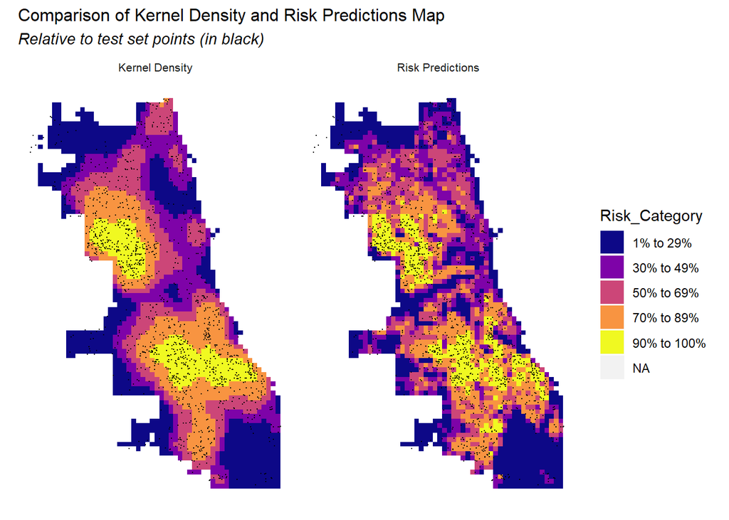

```r
rbind(batt_KDE_sf, batt_risk_sf) %>%
  gather(Variable, Value, -label, -Risk_Category, -geometry) %>%
  ggplot() +
    geom_sf(aes(fill = Risk_Category), colour = NA) +
    geom_sf(data = sample_n(dbatt, 1500), size = .1, colour = "black") +
    facet_wrap(~label, ) +
    scale_fill_viridis(discrete = TRUE, option = "C") +
    labs(title="Comparison of Kernel Density and Risk Predictions Map",
         subtitle="Relative to test set points (in black)") +
    mapTheme()
```

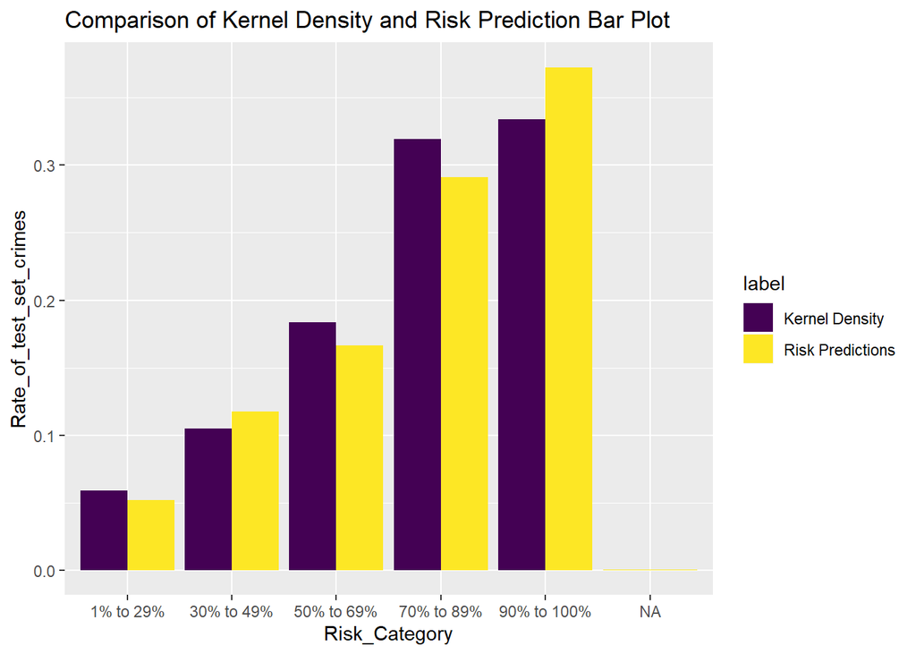

```r
rbind(batt_KDE_sf, batt_risk_sf) %>%
  st_set_geometry(NULL) %>%
  gather(Variable, Value, -label, -Risk_Category) %>%
  group_by(label, Risk_Category) %>%
  summarize(countBatt = sum(Value)) %>%
  ungroup() %>%
  group_by(label) %>%
  mutate(Rate_of_test_set_crimes = countBatt / sum(countBatt)) %>%
    ggplot(aes(Risk_Category,Rate_of_test_set_crimes)) +
      geom_bar(aes(fill=label), position="dodge", stat="identity") +
      labs(title = "Comparison of Kernel Density and Risk Prediction Bar Plot") +
      scale_fill_viridis(discrete = TRUE)
```

## 6. Conclusion

Even though the model is more accurate in predicting the high-risk regions than the current method of kernel density used by the Chicago Police, the model is unable to generalize across different racial and education groups, which might exasperate the selection bias and results in further over-policing. The above maps and barplot comparing the kernel density and the risk prediction results demonstrate that in general, our model is able to identify latent risks in the high-risk regions. This is useful to help the police force to identify potential risks and direct them for more efficient policing. However, the model also underpredicts the mid-risk regions, which might lead to insufficient policing in these regions.